# Risk Factor Analysis

## Outcome Variable

**Outcome Variable:** swasted

## Predictor Variables

**Intervention Variable:** vagbrth

**Adjustment Set:**

unadjusted

## Stratifying Variables

The analysis was stratified on these variable(s):

- agecat
- studyid
- country

## Data Summary

| agecat | studyid | country | vagbrth | swasted | n_cell | n |
| --- | --- | --- | --- | --- | --- | --- |
| Birth | ki1000108-CMC-V-BCS-2002 | INDIA | 0 | 0 | 10 | 86 |
| Birth | ki1000108-CMC-V-BCS-2002 | INDIA | 0 | 1 | 0 | 86 |
| Birth | ki1000108-CMC-V-BCS-2002 | INDIA | 1 | 0 | 75 | 86 |
| Birth | ki1000108-CMC-V-BCS-2002 | INDIA | 1 | 1 | 1 | 86 |
| Birth | ki1000108-IRC | INDIA | 0 | 0 | 52 | 343 |
| Birth | ki1000108-IRC | INDIA | 0 | 1 | 14 | 343 |
| Birth | ki1000108-IRC | INDIA | 1 | 0 | 237 | 343 |
| Birth | ki1000108-IRC | INDIA | 1 | 1 | 40 | 343 |
| Birth | ki1017093b-PROVIDE | BANGLADESH | 0 | 0 | 104 | 532 |
| Birth | ki1017093b-PROVIDE | BANGLADESH | 0 | 1 | 4 | 532 |
| Birth | ki1017093b-PROVIDE | BANGLADESH | 1 | 0 | 415 | 532 |
| Birth | ki1017093b-PROVIDE | BANGLADESH | 1 | 1 | 9 | 532 |
| Birth | ki1017093c-NIH-Crypto | BANGLADESH | 0 | 0 | 179 | 465 |
| Birth | ki1017093c-NIH-Crypto | BANGLADESH | 0 | 1 | 5 | 465 |
| Birth | ki1017093c-NIH-Crypto | BANGLADESH | 1 | 0 | 257 | 465 |
| Birth | ki1017093c-NIH-Crypto | BANGLADESH | 1 | 1 | 24 | 465 |
| Birth | ki1119695-PROBIT | BELARUS | 0 | 0 | 1502 | 13830 |
| Birth | ki1119695-PROBIT | BELARUS | 0 | 1 | 91 | 13830 |
| Birth | ki1119695-PROBIT | BELARUS | 1 | 0 | 11422 | 13830 |
| Birth | ki1119695-PROBIT | BELARUS | 1 | 1 | 815 | 13830 |
| Birth | ki1126311-ZVITAMBO | ZIMBABWE | 0 | 0 | 1016 | 12814 |
| Birth | ki1126311-ZVITAMBO | ZIMBABWE | 0 | 1 | 84 | 12814 |
| Birth | ki1126311-ZVITAMBO | ZIMBABWE | 1 | 0 | 11011 | 12814 |
| Birth | ki1126311-ZVITAMBO | ZIMBABWE | 1 | 1 | 703 | 12814 |
| Birth | kiGH5241-JiVitA-3 | BANGLADESH | 0 | 0 | 483 | 17985 |
| Birth | kiGH5241-JiVitA-3 | BANGLADESH | 0 | 1 | 17 | 17985 |
| Birth | kiGH5241-JiVitA-3 | BANGLADESH | 1 | 0 | 17154 | 17985 |
| Birth | kiGH5241-JiVitA-3 | BANGLADESH | 1 | 1 | 331 | 17985 |
| Birth | kiGH5241-JiVitA-4 | BANGLADESH | 0 | 0 | 70 | 2395 |
| Birth | kiGH5241-JiVitA-4 | BANGLADESH | 0 | 1 | 1 | 2395 |

[output cut: 74 more lines]

The following strata were considered:

- agecat: 24 months, studyid: ki1000108-CMC-V-BCS-2002, country: INDIA
- agecat: 24 months, studyid: ki1000108-IRC, country: INDIA
- agecat: 24 months, studyid: ki1017093b-PROVIDE, country: BANGLADESH
- agecat: 24 months, studyid: ki1017093c-NIH-Crypto, country: BANGLADESH
- agecat: 24 months, studyid: ki1066203-TanzaniaChild2, country: TANZANIA, UNITED REPUBLIC OF
- agecat: 24 months, studyid: ki1119695-PROBIT, country: BELARUS
- agecat: 24 months, studyid: ki1126311-ZVITAMBO, country: ZIMBABWE
- agecat: 24 months, studyid: kiGH5241-JiVitA-3, country: BANGLADESH
- agecat: 24 months, studyid: kiGH5241-JiVitA-4, country: BANGLADESH
- agecat: 6 months, studyid: ki1000108-CMC-V-BCS-2002, country: INDIA
- agecat: 6 months, studyid: ki1000108-IRC, country: INDIA
- agecat: 6 months, studyid: ki1017093b-PROVIDE, country: BANGLADESH
- agecat: 6 months, studyid: ki1017093c-NIH-Crypto, country: BANGLADESH
- agecat: 6 months, studyid: ki1066203-TanzaniaChild2, country: TANZANIA, UNITED REPUBLIC OF
- agecat: 6 months, studyid: ki1119695-PROBIT, country: BELARUS
- agecat: 6 months, studyid: ki1126311-ZVITAMBO, country: ZIMBABWE
- agecat: 6 months, studyid: kiGH5241-JiVitA-3, country: BANGLADESH
- agecat: 6 months, studyid: kiGH5241-JiVitA-4, country: BANGLADESH
- agecat: Birth, studyid: ki1000108-CMC-V-BCS-2002, country: INDIA
- agecat: Birth, studyid: ki1000108-IRC, country: INDIA
- agecat: Birth, studyid: ki1017093b-PROVIDE, country: BANGLADESH
- agecat: Birth, studyid: ki1017093c-NIH-Crypto, country: BANGLADESH
- agecat: Birth, studyid: ki1119695-PROBIT, country: BELARUS
- agecat: Birth, studyid: ki1126311-ZVITAMBO, country: ZIMBABWE
- agecat: Birth, studyid: kiGH5241-JiVitA-3, country: BANGLADESH
- agecat: Birth, studyid: kiGH5241-JiVitA-4, country: BANGLADESH

### Dropped Strata

Some strata were dropped due to rare outcomes:

- agecat: Birth, studyid: ki1000108-CMC-V-BCS-2002, country: INDIA
- agecat: Birth, studyid: ki1017093b-PROVIDE, country: BANGLADESH
- agecat: Birth, studyid: kiGH5241-JiVitA-4, country: BANGLADESH
- agecat: 6 months, studyid: ki1000108-CMC-V-BCS-2002, country: INDIA
- agecat: 6 months, studyid: ki1000108-IRC, country: INDIA
- agecat: 6 months, studyid: ki1017093b-PROVIDE, country: BANGLADESH
- agecat: 6 months, studyid: ki1017093c-NIH-Crypto, country: BANGLADESH
- agecat: 6 months, studyid: ki1066203-TanzaniaChild2, country: TANZANIA, UNITED REPUBLIC OF
- agecat: 6 months, studyid: ki1119695-PROBIT, country: BELARUS
- agecat: 6 months, studyid: kiGH5241-JiVitA-4, country: BANGLADESH
- agecat: 24 months, studyid: ki1000108-CMC-V-BCS-2002, country: INDIA
- agecat: 24 months, studyid: ki1000108-IRC, country: INDIA
- agecat: 24 months, studyid: ki1017093b-PROVIDE, country: BANGLADESH
- agecat: 24 months, studyid: ki1017093c-NIH-Crypto, country: BANGLADESH
- agecat: 24 months, studyid: ki1066203-TanzaniaChild2, country: TANZANIA, UNITED REPUBLIC OF
- agecat: 24 months, studyid: ki1119695-PROBIT, country: BELARUS
- agecat: 24 months, studyid: ki1126311-ZVITAMBO, country: ZIMBABWE

## Methods Detail

We’re interested in the causal parameters $E[Y_a]$ for all values of $a \in \mathcal{A}$. These parameters represent the mean outcome if, possibly contrary to fact, we intervened to set all units to have $A=a$. Under the randomization and positivity assumptions, these are identified by the statistical parameters $\psi_a=E_W[E_{Y|A,W}(Y|A=a,W)]$. In addition, we’re interested in the mean of $Y$, $E[Y]$ under no intervention (the observed mean). We will estimate these parameters by using SuperLearner to fit the relevant likelihood factors – $E_{Y|A,W}(Y|A=a,W)$ and $p(A=a|W)$, and then updating our likelihood fit using a joint TMLE.

For unadjusted analyses ($W=\{\}$), initial likelihoods were estimated using Lrnr_glm to estimate the simple $E(Y|A)$ and Lrnr_mean to estimate $p(A)$. For adjusted analyses, a small library containing Lrnr_glmnet, Lrnr_xgboost, and Lrnr_mean was used.

Having estimated these parameters, we will then use the delta method to estimate relative risks and attributable risks relative to a prespecified baseline level of $A$.

# Results Detail

## Results Plots

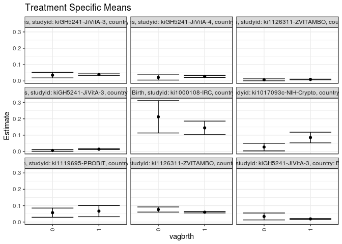

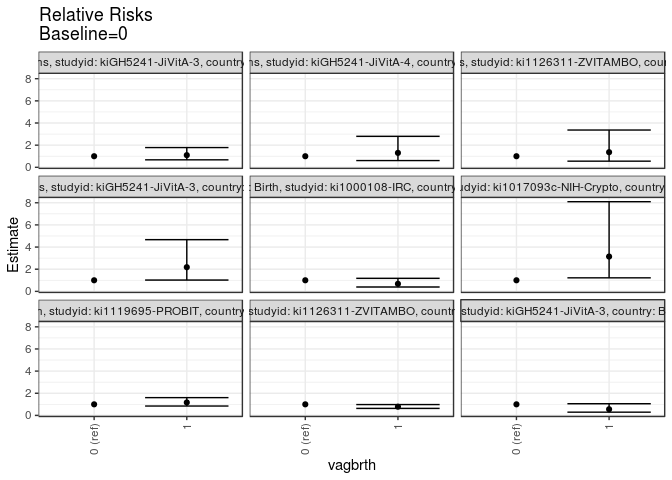

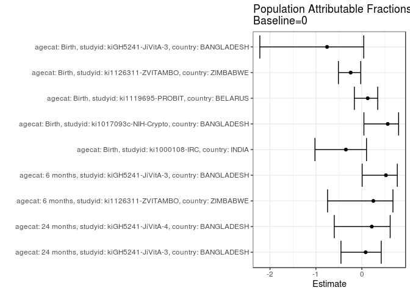

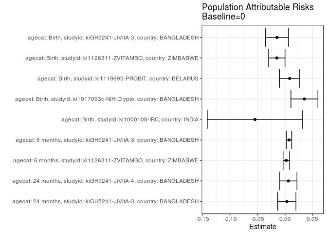

## Results Table

### Parameter: TSM

| agecat | studyid | country | intervention_level | baseline_level | estimate | ci_lower | ci_upper |
| --- | --- | --- | --- | --- | --- | --- | --- |
| Birth | ki1000108-IRC | INDIA | 0 | NA | 0.2121212 | 0.1133497 | 0.3108928 |
| Birth | ki1000108-IRC | INDIA | 1 | NA | 0.1444043 | 0.1029503 | 0.1858583 |
| Birth | ki1017093c-NIH-Crypto | BANGLADESH | 0 | NA | 0.0271739 | 0.0036559 | 0.0506919 |
| Birth | ki1017093c-NIH-Crypto | BANGLADESH | 1 | NA | 0.0854093 | 0.0526957 | 0.1181228 |
| Birth | ki1119695-PROBIT | BELARUS | 0 | NA | 0.0571249 | 0.0289839 | 0.0852659 |
| Birth | ki1119695-PROBIT | BELARUS | 1 | NA | 0.0666013 | 0.0323207 | 0.1008818 |
| Birth | ki1126311-ZVITAMBO | ZIMBABWE | 0 | NA | 0.0763636 | 0.0606686 | 0.0920587 |
| Birth | ki1126311-ZVITAMBO | ZIMBABWE | 1 | NA | 0.0600137 | 0.0557124 | 0.0643149 |
| Birth | kiGH5241-JiVitA-3 | BANGLADESH | 0 | NA | 0.0340000 | 0.0128817 | 0.0551183 |
| Birth | kiGH5241-JiVitA-3 | BANGLADESH | 1 | NA | 0.0189305 | 0.0165356 | 0.0213254 |
| 6 months | ki1126311-ZVITAMBO | ZIMBABWE | 0 | NA | 0.0069348 | 0.0008770 | 0.0129926 |
| 6 months | ki1126311-ZVITAMBO | ZIMBABWE | 1 | NA | 0.0094609 | 0.0073007 | 0.0116210 |
| 6 months | kiGH5241-JiVitA-3 | BANGLADESH | 0 | NA | 0.0065116 | 0.0016099 | 0.0114134 |
| 6 months | kiGH5241-JiVitA-3 | BANGLADESH | 1 | NA | 0.0142035 | 0.0120341 | 0.0163728 |
| 24 months | kiGH5241-JiVitA-3 | BANGLADESH | 0 | NA | 0.0357895 | 0.0189031 | 0.0526759 |
| 24 months | kiGH5241-JiVitA-3 | BANGLADESH | 1 | NA | 0.0392327 | 0.0347479 | 0.0437174 |
| 24 months | kiGH5241-JiVitA-4 | BANGLADESH | 0 | NA | 0.0216718 | 0.0056736 | 0.0376701 |
| 24 months | kiGH5241-JiVitA-4 | BANGLADESH | 1 | NA | 0.0282225 | 0.0220464 | 0.0343986 |

### Parameter: E(Y)

| agecat | studyid | country | intervention_level | baseline_level | estimate | ci_lower | ci_upper |
| --- | --- | --- | --- | --- | --- | --- | --- |
| Birth | ki1000108-IRC | INDIA | NA | NA | 0.1574344 | 0.1188345 | 0.1960344 |
| Birth | ki1017093c-NIH-Crypto | BANGLADESH | NA | NA | 0.0623656 | 0.0403628 | 0.0843684 |
| Birth | ki1119695-PROBIT | BELARUS | NA | NA | 0.0655098 | 0.0324802 | 0.0985393 |
| Birth | ki1126311-ZVITAMBO | ZIMBABWE | NA | NA | 0.0614172 | 0.0572600 | 0.0655744 |
| Birth | kiGH5241-JiVitA-3 | BANGLADESH | NA | NA | 0.0193495 | 0.0169634 | 0.0217355 |
| 6 months | ki1126311-ZVITAMBO | ZIMBABWE | NA | NA | 0.0092450 | 0.0072027 | 0.0112873 |
| 6 months | kiGH5241-JiVitA-3 | BANGLADESH | NA | NA | 0.0137085 | 0.0116390 | 0.0157780 |
| 24 months | kiGH5241-JiVitA-3 | BANGLADESH | NA | NA | 0.0390415 | 0.0347089 | 0.0433741 |
| 24 months | kiGH5241-JiVitA-4 | BANGLADESH | NA | NA | 0.0276946 | 0.0218340 | 0.0335552 |

### Parameter: RR

| agecat | studyid | country | intervention_level | baseline_level | estimate | ci_lower | ci_upper |
| --- | --- | --- | --- | --- | --- | --- | --- |
| Birth | ki1000108-IRC | INDIA | 0 | 0 | 1.0000000 | 1.0000000 | 1.0000000 |
| Birth | ki1000108-IRC | INDIA | 1 | 0 | 0.6807633 | 0.3939399 | 1.1764196 |
| Birth | ki1017093c-NIH-Crypto | BANGLADESH | 0 | 0 | 1.0000000 | 1.0000000 | 1.0000000 |
| Birth | ki1017093c-NIH-Crypto | BANGLADESH | 1 | 0 | 3.1430605 | 1.2198971 | 8.0980841 |
| Birth | ki1119695-PROBIT | BELARUS | 0 | 0 | 1.0000000 | 1.0000000 | 1.0000000 |
| Birth | ki1119695-PROBIT | BELARUS | 1 | 0 | 1.1658885 | 0.8470583 | 1.6047255 |
| Birth | ki1126311-ZVITAMBO | ZIMBABWE | 0 | 0 | 1.0000000 | 1.0000000 | 1.0000000 |
| Birth | ki1126311-ZVITAMBO | ZIMBABWE | 1 | 0 | 0.7858932 | 0.6321662 | 0.9770026 |
| Birth | kiGH5241-JiVitA-3 | BANGLADESH | 0 | 0 | 1.0000000 | 1.0000000 | 1.0000000 |
| Birth | kiGH5241-JiVitA-3 | BANGLADESH | 1 | 0 | 0.5567798 | 0.2942887 | 1.0534001 |
| 6 months | ki1126311-ZVITAMBO | ZIMBABWE | 0 | 0 | 1.0000000 | 1.0000000 | 1.0000000 |
| 6 months | ki1126311-ZVITAMBO | ZIMBABWE | 1 | 0 | 1.3642561 | 0.5530721 | 3.3651932 |
| 6 months | kiGH5241-JiVitA-3 | BANGLADESH | 0 | 0 | 1.0000000 | 1.0000000 | 1.0000000 |
| 6 months | kiGH5241-JiVitA-3 | BANGLADESH | 1 | 0 | 2.1812447 | 1.0194849 | 4.6668944 |
| 24 months | kiGH5241-JiVitA-3 | BANGLADESH | 0 | 0 | 1.0000000 | 1.0000000 | 1.0000000 |
| 24 months | kiGH5241-JiVitA-3 | BANGLADESH | 1 | 0 | 1.0962070 | 0.6740508 | 1.7827587 |
| 24 months | kiGH5241-JiVitA-4 | BANGLADESH | 0 | 0 | 1.0000000 | 1.0000000 | 1.0000000 |
| 24 months | kiGH5241-JiVitA-4 | BANGLADESH | 1 | 0 | 1.3022679 | 0.6065679 | 2.7958972 |

### Parameter: PAR

| agecat | studyid | country | intervention_level | baseline_level | estimate | ci_lower | ci_upper |
| --- | --- | --- | --- | --- | --- | --- | --- |
| Birth | ki1000108-IRC | INDIA | 0 | NA | -0.0546868 | -0.1412394 | 0.0318658 |
| Birth | ki1017093c-NIH-Crypto | BANGLADESH | 0 | NA | 0.0351917 | 0.0107070 | 0.0596764 |
| Birth | ki1119695-PROBIT | BELARUS | 0 | NA | 0.0083848 | -0.0098609 | 0.0266306 |
| Birth | ki1126311-ZVITAMBO | ZIMBABWE | 0 | NA | -0.0149464 | -0.0298234 | -0.0000695 |
| Birth | kiGH5241-JiVitA-3 | BANGLADESH | 0 | NA | -0.0146505 | -0.0353757 | 0.0060746 |
| 6 months | ki1126311-ZVITAMBO | ZIMBABWE | 0 | NA | 0.0023102 | -0.0035716 | 0.0081920 |
| 6 months | kiGH5241-JiVitA-3 | BANGLADESH | 0 | NA | 0.0071968 | 0.0022767 | 0.0121170 |
| 24 months | kiGH5241-JiVitA-3 | BANGLADESH | 0 | NA | 0.0032520 | -0.0132789 | 0.0197829 |
| 24 months | kiGH5241-JiVitA-4 | BANGLADESH | 0 | NA | 0.0060228 | -0.0095887 | 0.0216342 |

### Parameter: PAF

| agecat | studyid | country | intervention_level | baseline_level | estimate | ci_lower | ci_upper |
| --- | --- | --- | --- | --- | --- | --- | --- |
| Birth | ki1000108-IRC | INDIA | 0 | NA | -0.3473625 | -1.0213073 | 0.1018754 |
| Birth | ki1017093c-NIH-Crypto | BANGLADESH | 0 | NA | 0.5642804 | 0.0453422 | 0.8011313 |
| Birth | ki1119695-PROBIT | BELARUS | 0 | NA | 0.1279937 | -0.1625659 | 0.3459340 |
| Birth | ki1126311-ZVITAMBO | ZIMBABWE | 0 | NA | -0.2433591 | -0.5102221 | -0.0236520 |
| Birth | kiGH5241-JiVitA-3 | BANGLADESH | 0 | NA | -0.7571551 | -2.2213047 | 0.0415082 |
| 6 months | ki1126311-ZVITAMBO | ZIMBABWE | 0 | NA | 0.2498844 | -0.7462542 | 0.6777826 |
| 6 months | kiGH5241-JiVitA-3 | BANGLADESH | 0 | NA | 0.5249924 | 0.0071734 | 0.7727375 |
| 24 months | kiGH5241-JiVitA-3 | BANGLADESH | 0 | NA | 0.0832966 | -0.4543321 | 0.4221779 |
| 24 months | kiGH5241-JiVitA-4 | BANGLADESH | 0 | NA | 0.2174713 | -0.6006481 | 0.6174355 |